# The Propensity to Cycle Tool: An on-line interactive web tool for transport planning

19th Nov. 2015, UCL Geospatial Science Seminar Series

## Presentation structure

- Introduction
- Open source geospatial software
- Propensity to Cycle Tool
- Live demo
- Bonus: research ideas

## Introduction

## A little about me

[figure not shown]

http://groups.energyshare.com/ewb-sheffield-wind/

## Career progression

- Geography
- Bicycle mechanic
- Environmental science
- Some engineering!
- Energy studies
- Geography (with computers!)
- Transport studies

## The wider context

[figure not shown]

## I: Software

## Transport planning tools: expensive…

[figure not shown]

## And difficult..

Proprietary software cannot be:

- modified
- shared
- updated

## And dangerous!

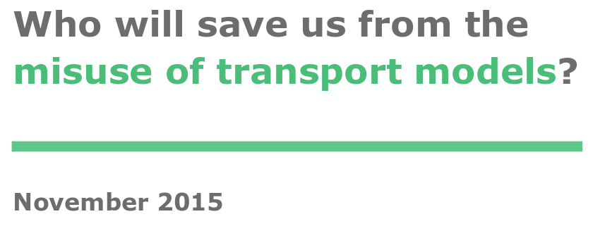

Source: [Who will save us from transport models](http://www.ctthink.com/publications.html) (Hollander 2015)

## The solution

- Go Open Source!

[figure not shown]

## Jobs

- The global transition away from fossil fuels is big business
- Many cities are scrambling to make their cities healthier and cleaner
- Check out some of the jobs that are available, decide which one YOU want

Good transport companies - ready for a transition away from fossil fuels:

- [Arup](http://www.arup.com/Services/Transport_Consulting.aspx)
- [Steer Davies Gleave](http://www.steerdaviesgleave.com/)

## Opportunities

[figure not shown]

## New tools of the trade

- QGIS
- GRASS
- R
- Python

## Program or be programmed

[figure not shown]

## R's spatial ecosystem

[figure not shown]

http://www.maths.lancs.ac.uk/~rowlings/Teaching/UseR2012/introduction2Talk.html

## QGIS

[figure not shown]

## New software: aequilibrae

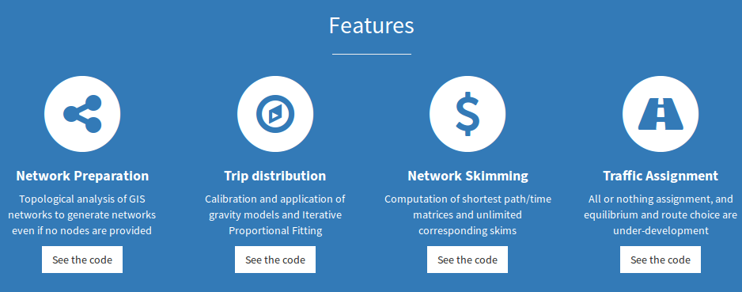

http://www.aequilibrae.com/

## Why R?

See the free, open source, online tutorial [github.com/robinlovelace/Creating-maps-in-R](https://github.com/Robinlovelace/Creating-maps-in-R).

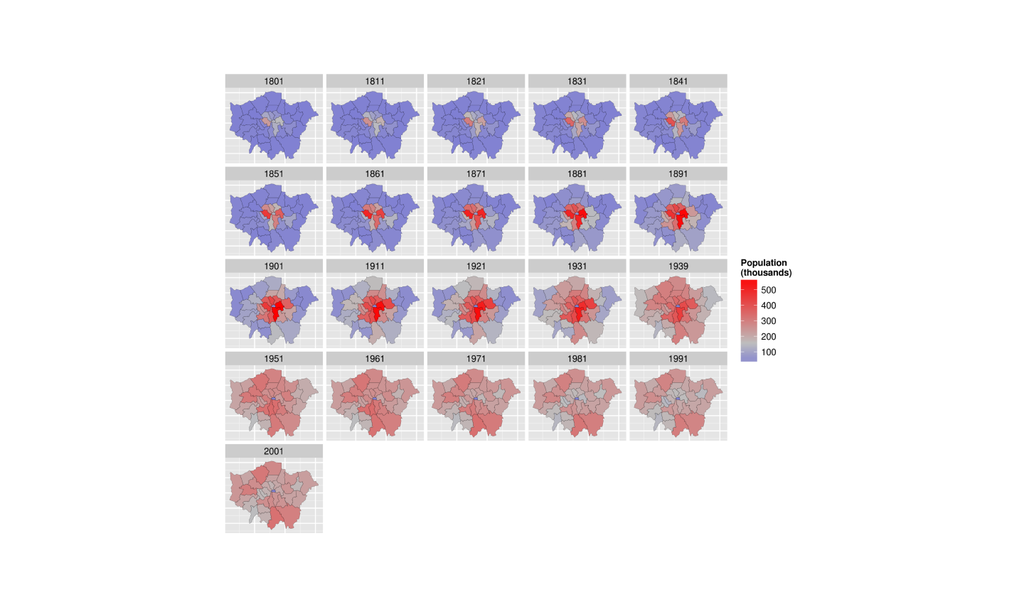

## The packages used

Can be installed and loaded in 6 lines of code:

```r
pkgs <- c("devtools", "shiny", "rgdal", "rgeos", "ggmap") # official packages
install.packages(pkgs)
library(devtools) # enables installation of leaflet
gh_pkgs <- c("rstudio/leaflet", "robinlovelace/stplanr")
install_github(gh_pkgs) # install packages on github
lapply(c(pkgs, "leaflet", "stplanr"), library, character.only = T) # load all
```

## RStudio

RStudio Desktop is highly recommended for Shiny development.

[figure not shown]

## Shiny

**shiny** is a framework for creating online interactive data visualisation 'apps'.

- A framework for making R output **interactive**
- An 'app' development framework
- A (small) growing community of developers centred around RStudio
- A way to structure online tools: separation of GUI and server via `server.R` and `ui.R` files.

## Alternatives

- **animate** package
- Google Charts (**googleVis::**) and
- **plotly**
- D3
- Tableau

For maps

- Leaflet (supported by Shiny)
- Google Maps API

## What's shiny good (and not so good) for?

Build's on R's existing strengths

- Data visualisation (ggplot2)
- Increasingline widely understood language for querying data
- Amazing range of add-on packages

*Flexibility*

Not so good for

- Scalability
- Database interaction
- Low-level control

## What do shiny apps look like?

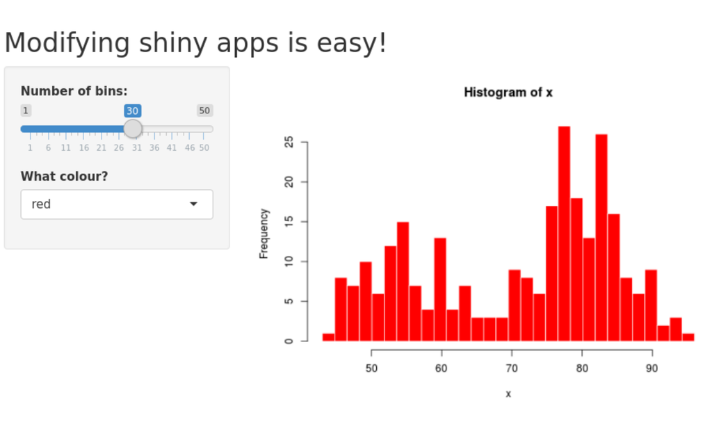

```r
# type this to find out!
runExample()
```

## More examples

See geo8.webarch.net/robin/rentSplit/

GEOSTAT 2015 Visualisation Competition winner: geo8.webarch.net/robin/vizcomp/

## Leaflet

An R interface to the Leaflet JavaScript library, compatible with Shiny.

```r
cent <- geocode("Girona")
leaflet() %>%
  addTiles() %>%
  addCircleMarkers(data = cent)
```

## II: The propensity to cycle tool (PCT)

## Policy context

- House of Commons Criticising the DfT for using closed models
- 'Impact' and 'engagement' increasingly important for research funding
- Complex data cannot be adequately summarised in a single static graphic
- Phase I: proof of concept (February - August 2015)
- Phase II: nationwide deployment (November 2015 - 2018)

See: [cedar.iph.cam.ac.uk/research/modelling/npct-tool](http://www.cedar.iph.cam.ac.uk/research/modelling/npct-tool/)

## Interactive online tools

- [AURIN](http://aurin.org.au/)
- Leeds-Bradford cycle path [interactive map](http://www.cyclecityconnect.co.uk/participate.php)
- DECC's 'Energy 2050' [planning tool](http://2050-calculator-tool.decc.gov.uk/)
- Walkability index site
- Interactive download of bicycle paths

## Design criteria

- Interactive basemap
- Points, lines and polygons
- Cascading effects of different scenarios > - Tidy!

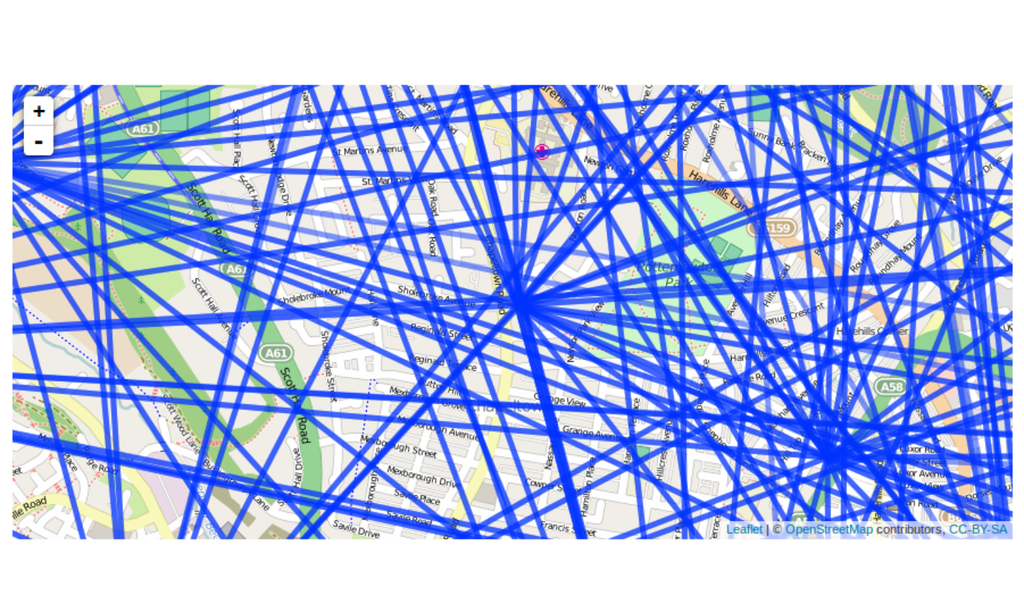

## Early user testing

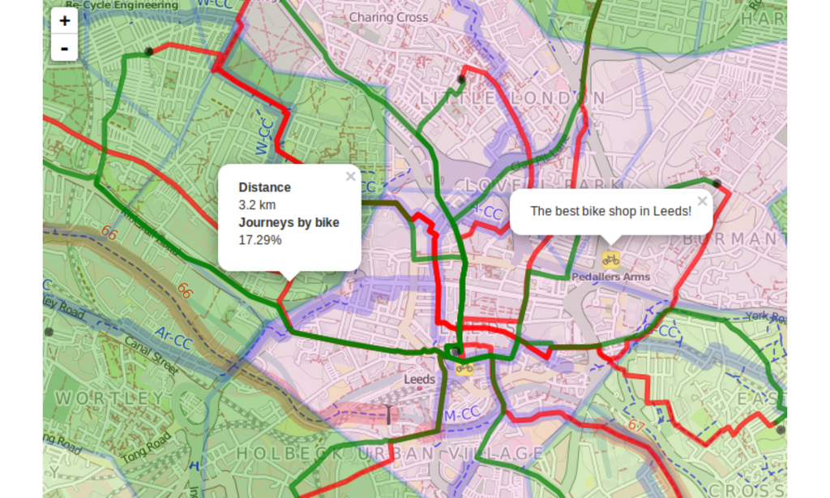

## The underlying theory

- Check out our paper: http://arxiv.org/abs/1509.04425

## Live demo!

See here: [geo8.webarch.net/master](http://geo8.webarch.net/manchester/)

[figure not shown]

## Zoom-dependent selection and freeze Scope

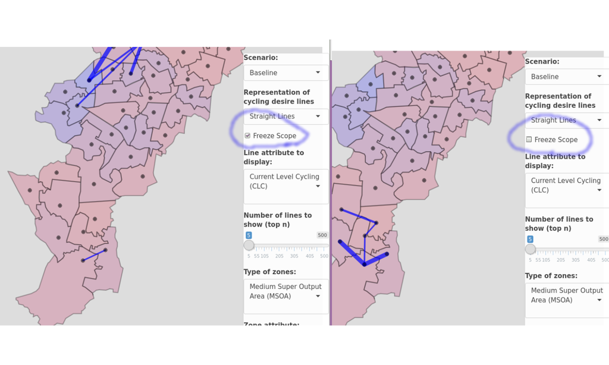

[figure not shown]

## Model output tab II: Manchester

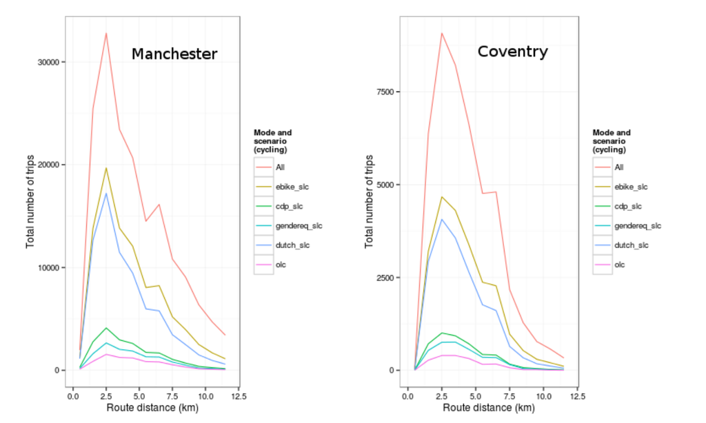

## Planned feature: network tab

> Estimating cycling rate allocated to the road network with https://t.co/DuzyCQCA50. Looks like streams + rivers! [pic.twitter.com/geaV0mVKdG](http://t.co/geaV0mVKdG)

> — Robin Lovelace (@robinlovelace) [August 17, 2015](https://twitter.com/robinlovelace/status/633152722926206976)

## Other planned features

**Beta**

- Network analysis (various options)
- Hilliness allocated to cycle network

**Version 1 - nationwide (June 2016)**

- HEAT outputs
- Incorporation of user feedback
- Travel to school layer (data pending)

**Version 2 - nationwide (June 2017)**

- Micro-level analysis
- Socio-demographic variables (new scenarios?)

## Potential futures: e.g. community contributed

- Custom scenarios (e.g. 20% cycling by 2020 in Bristol)
- Custom scenarios (e.g. 10% cycling by 2020 in Manchester!)
- Scenarios estimating impacts from specific interventions
- International comparisons of propensity to cycle
- A global propensity to cycle map?

## Fork my code!

[figure not shown]

- The work is open source so can used as a foundation for further work by others
- E.g. councils with the technical know-how
- E.g. cycle campaigner 'hackers'
- Check out the project's repository: github.com/npct/pct-shiny

## Example: Trinity Way, Manchester

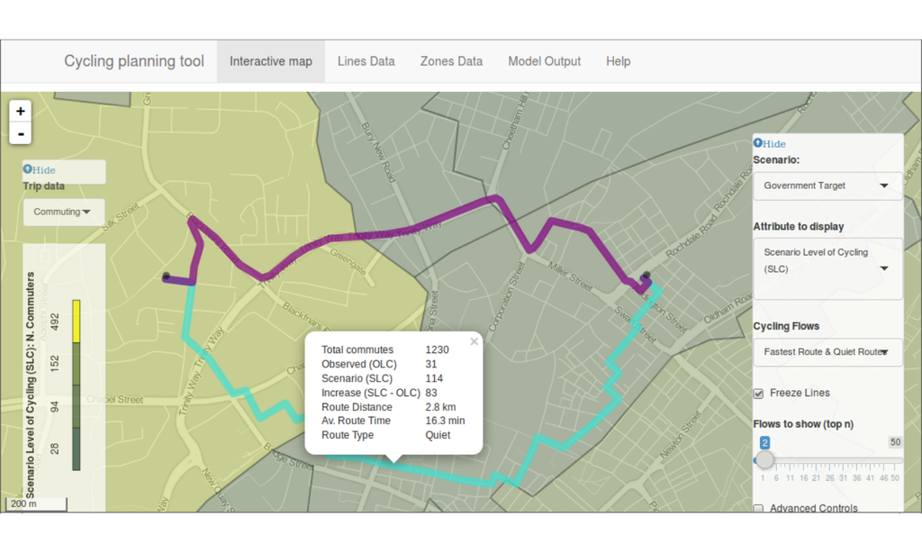

## IV Live demo!

## V Study ideas

## 1: identify what you're motivated by

[figure not shown]

## How could transport infrastructure change if people worked from home?

[figure not shown]

## How best to reallocate space away from cars?

[figure not shown]

## How transport engineers can encourage car sharing?

## Links and references

- R vs QGIS for transport planning: http://robinlovelace.net/r/2015/04/20/r-vs-qgis-for-transport.html
- Aequillibrea: transport planning toolbox - http://www.aequilibrae.com/
- Lovelace, R., Goodman, A., Aldred, R., Berkoff, N., Abbas, A., & Woodcock, J. (2015). The Propensity to Cycle Tool: An open source online system for sustainable transport planning. arXiv preprint arXiv:1509.04425.
- Use Google and your imagination
- Code is good but start with a pen and paper!